# Machine Learning Project - Poisson

Jeanette Lee

05 January 2022

# 1 Setup

```r
library(magrittr)
library(data.table)
library(dplyr)
library(lubridate)
library(caret)
library(knitr)
library(inspectdf)
library(ggplot2)
library(GGally)
library(gridExtra)
library(car)
#library(multcomp)

opts_chunk$set(fig.align="center", echo=TRUE)
knit_hooks$set(inline=function(x) { prettyNum(x, big.mark=",") })
```

# 2 Data Preparation

## 2.1 Data Import

```r
df.ar <- fread("data/application_record.csv", stringsAsFactors = TRUE)
df.cr <- fread("data/credit_record.csv", stringsAsFactors = TRUE)
```

## 2.2 View Data

### 2.2.1 Application Record Dataframe

This dataset includes the demographic data of applicants.  
- DAYS_BIRTH and DAYS_EMPLOYED columns count backwards from “current” day (0), yesterday (-1), etc.  
- DAYS_EMPLOYED is positive, if the person is currently unemployed

**Data Summary**

```
## Classes 'data.table' and 'data.frame':   438557 obs. of  18 variables:
##  $ ID                 : int  5008804 5008805 5008806 5008808 5008809 5008810 5008811 5008812 5008813 5008814 ...
##  $ CODE_GENDER        : Factor w/ 2 levels "F","M": 2 2 2 1 1 1 1 1 1 1 ...
##  $ FLAG_OWN_CAR       : Factor w/ 2 levels "N","Y": 2 2 2 1 1 1 1 1 1 1 ...
##  $ FLAG_OWN_REALTY    : Factor w/ 2 levels "N","Y": 2 2 2 2 2 2 2 2 2 2 ...
##  $ CNT_CHILDREN       : int  0 0 0 0 0 0 0 0 0 0 ...
##  $ AMT_INCOME_TOTAL   : num  427500 427500 112500 270000 270000 ...
##  $ NAME_INCOME_TYPE   : Factor w/ 5 levels "Commercial associate",..: 5 5 5 1 1 1 1 2 2 2 ...
##  $ NAME_EDUCATION_TYPE: Factor w/ 5 levels "Academic degree",..: 2 2 5 5 5 5 5 2 2 2 ...
##  $ NAME_FAMILY_STATUS : Factor w/ 5 levels "Civil marriage",..: 1 1 2 4 4 4 4 3 3 3 ...
##  $ NAME_HOUSING_TYPE  : Factor w/ 6 levels "Co-op apartment",..: 5 5 2 2 2 2 2 2 2 2 ...
##  $ DAYS_BIRTH         : int  -12005 -12005 -21474 -19110 -19110 -19110 -19110 -22464 -22464 -22464 ...
##  $ DAYS_EMPLOYED      : int  -4542 -4542 -1134 -3051 -3051 -3051 -3051 365243 365243 365243 ...
##  $ FLAG_MOBIL         : int  1 1 1 1 1 1 1 1 1 1 ...
##  $ FLAG_WORK_PHONE    : int  1 1 0 0 0 0 0 0 0 0 ...
##  $ FLAG_PHONE         : int  0 0 0 1 1 1 1 0 0 0 ...
##  $ FLAG_EMAIL         : int  0 0 0 1 1 1 1 0 0 0 ...
##  $ OCCUPATION_TYPE    : Factor w/ 19 levels "","Accountants",..: 1 1 18 16 16 16 16 1 1 1 ...
##  $ CNT_FAM_MEMBERS    : num  2 2 2 1 1 1 1 1 1 1 ...
##  - attr(*, ".internal.selfref")=<externalptr>
```

**Sample of Dataset**

| ID | CODE_GENDER | FLAG_OWN_CAR | FLAG_OWN_REALTY | CNT_CHILDREN | AMT_INCOME_TOTAL | NAME_INCOME_TYPE | NAME_EDUCATION_TYPE | NAME_FAMILY_STATUS | NAME_HOUSING_TYPE | DAYS_BIRTH | DAYS_EMPLOYED | FLAG_MOBIL | FLAG_WORK_PHONE | FLAG_PHONE | FLAG_EMAIL | OCCUPATION_TYPE | CNT_FAM_MEMBERS |
| --- | --- | --- | --- | --- | --- | --- | --- | --- | --- | --- | --- | --- | --- | --- | --- | --- | --- |
| 5008804 | M | Y | Y | 0 | 427500 | Working | Higher education | Civil marriage | Rented apartment | -12005 | -4542 | 1 | 1 | 0 | 0 |  | 2 |
| 5008805 | M | Y | Y | 0 | 427500 | Working | Higher education | Civil marriage | Rented apartment | -12005 | -4542 | 1 | 1 | 0 | 0 |  | 2 |
| 5008806 | M | Y | Y | 0 | 112500 | Working | Secondary / secondary special | Married | House / apartment | -21474 | -1134 | 1 | 0 | 0 | 0 | Security staff | 2 |
| 5008808 | F | N | Y | 0 | 270000 | Commercial associate | Secondary / secondary special | Single / not married | House / apartment | -19110 | -3051 | 1 | 0 | 1 | 1 | Sales staff | 1 |
| 5008809 | F | N | Y | 0 | 270000 | Commercial associate | Secondary / secondary special | Single / not married | House / apartment | -19110 | -3051 | 1 | 0 | 1 | 1 | Sales staff | 1 |
| 5008810 | F | N | Y | 0 | 270000 | Commercial associate | Secondary / secondary special | Single / not married | House / apartment | -19110 | -3051 | 1 | 0 | 1 | 1 | Sales staff | 1 |

### 2.2.2 Credit Record Dataframe

This dataset includes the historical data of user behaviour.  
- MONTHS_BALANCE column counts backward from “current” month (0), previous month (-1), 2 months prior (-2), etc.  
- STATUS column: 0 = 1-29 days past due, 1 = 30-59 days past due, 2 = 60-89 days overdue, 3 = 90-119 days overdue, 4 = 120-149 days overdue, 5 = overdue or bad debts, write-offs for more than 150 days, C = paid off that month, X = no loan for the month

**Data Summary**

```
## Classes 'data.table' and 'data.frame':   1048575 obs. of  3 variables:
##  $ ID            : int  5001711 5001711 5001711 5001711 5001712 5001712 5001712 5001712 5001712 5001712 ...
##  $ MONTHS_BALANCE: int  0 -1 -2 -3 0 -1 -2 -3 -4 -5 ...
##  $ STATUS        : Factor w/ 8 levels "0","1","2","3",..: 8 1 1 1 7 7 7 7 7 7 ...
##  - attr(*, ".internal.selfref")=<externalptr>
```

**Sample of Dataset**

| ID | MONTHS_BALANCE | STATUS |
| --- | --- | --- |
| 5001711 | 0 | X |
| 5001711 | -1 | 0 |
| 5001711 | -2 | 0 |
| 5001711 | -3 | 0 |
| 5001712 | 0 | C |
| 5001712 | -1 | C |

## 2.3 Cleaning and Joining Datasets

### 2.3.1 Cleaning application_record.csv

Removed duplicate IDs from application_record.csv

```r
duplicates <- df.ar %>% group_by(ID) %>% summarise(count = n()) %>% filter(count > 1)
df.ar.mod <- df.ar %>% filter(!ID %in% duplicates$ID)
```

### 2.3.2 Cleaning credit_record.csv

The original dataset was made available on 24-03-2020, so it is presumed “current” month is March 2020. From months_balance we create a new column indicating the month for each observation. Observations older than 2 years are removed.

```r
# Extract month and year from months_balance in df.cr
df.cr$month_balance <- format(as.Date("2020-03-24") %m+% months(df.cr$MONTHS_BALANCE), "%B")

# Remove records older than 2 years
df.cr.mod <- df.cr %>% filter(MONTHS_BALANCE > -24)

# Assign customer status
df.status <- df.cr.mod %>% group_by(ID) %>%
  summarise(cnt_status_good = length(STATUS[STATUS==0|STATUS==1|STATUS=='C']),
            cnt_status_bad = n() - cnt_status_good,
            percent_good = round(cnt_status_good / n() * 100)) %>%
  mutate(customer_status_good = ifelse(percent_good >= 50, 1, 0)) %>%
  select(ID, customer_status_good, percent_good, cnt_status_good, cnt_status_bad)

df.status$customer_status_good <- as.factor(df.status$customer_status_good)
```

### 2.3.3 Join datasets

The two cleaned datasets are joined and only records where IDs exist in both are kept.

```r
df.cc.raw <- inner_join(x = df.status, y = df.ar.mod, by = "ID") %>%
  mutate(ID = as.factor(ID),
         CNT_FAM_MEMBERS = as.integer(CNT_FAM_MEMBERS),
         age_years = as.numeric(round(DAYS_BIRTH * (-1) / 365.25), 0),       # days -> years
         work_years = as.numeric(round((DAYS_EMPLOYED * (-1) / 365.25), 0)), # days -> years
         FLAG_MOBIL = as.factor(FLAG_MOBIL),
         FLAG_WORK_PHONE = as.factor(FLAG_WORK_PHONE),
         FLAG_PHONE = as.factor(FLAG_PHONE),
         FLAG_EMAIL = as.factor(FLAG_EMAIL))

setnames(df.cc.raw, tolower(names(df.cc.raw)))   # change column names to lower case
```

```r
df.cc.raw %>% select(-id) %>% select_if(is.factor) %>% sapply(., FUN = table)
table(df.cc.raw$cnt_fam_members)
table(df.cc.raw$cnt_children)
```

```r
df.cc.raw <- df.cc.raw[df.cc.raw$cnt_fam_members < 7, ]

# combine 'Academic degree' with 'Higher education' and set order of levels in education type
df.cc.raw$name_education_type <- recode_factor(df.cc.raw$name_education_type, "Academic degree" = "Higher education")
df.cc.raw$name_education_type <- factor(df.cc.raw$name_education_type, levels=c("Lower secondary", "Secondary / secondary special", "Incomplete higher", "Higher education"), ordered = TRUE)

df.cc.raw$work_years[df.cc.raw$work_years == '-1000'] <- NA                  # -ve = pensioner
levels(df.cc.raw$occupation_type)[levels(df.cc.raw$occupation_type)==""] <- "NA"

# select columns (exclude months_balance, days_birth, days_employed and flag_mobil)
df.cc <- df.cc.raw %>%
  select(id,
         code_gender,
         age_years,
         name_education_type,
         name_income_type,
         name_housing_type,
         name_family_status,
         cnt_children,
         cnt_fam_members,
         flag_own_car,
         flag_own_realty,
         work_years,
         amt_income_total,
         occupation_type,
         flag_work_phone,
         flag_phone,
         flag_email,
         customer_status_good,
         percent_good,
         cnt_status_good,
         cnt_status_bad)
```

### 2.3.4 Remove duplicates and NA

Some IDs appear to be the same individual (with different IDs) as all other columns are the same. We only keep one observation, removing duplicates.

```r
df.cc <- df.cc[!duplicated(df.cc[c(2:17)]),]
df.cc <- na.omit(df.cc)                                                        # remove NA-values
```

### 2.3.5 Check Final Dataframe

**Data Summary**

```
## tibble [7,832 x 21] (S3: tbl_df/tbl/data.frame)
##  $ id                  : Factor w/ 32848 levels "5008804","5008805",..: 1 3 4 11 12 18 21 24 25 27 ...
##  $ code_gender         : Factor w/ 2 levels "F","M": 2 2 1 2 2 1 1 1 2 2 ...
##  $ age_years           : num [1:7832] 33 59 52 46 49 29 27 30 35 32 ...
##  $ name_education_type : Ord.factor w/ 4 levels "Lower secondary"<..: 4 2 2 4 2 3 2 2 2 4 ...
##  $ name_income_type    : Factor w/ 5 levels "Commercial associate",..: 5 5 1 5 1 5 5 5 5 1 ...
##  $ name_housing_type   : Factor w/ 6 levels "Co-op apartment",..: 5 2 2 2 2 2 2 2 2 2 ...
##  $ name_family_status  : Factor w/ 5 levels "Civil marriage",..: 1 2 4 2 2 2 2 4 2 2 ...
##  $ cnt_children        : int [1:7832] 0 0 0 0 0 0 0 1 3 1 ...
##  $ cnt_fam_members     : int [1:7832] 2 2 1 2 2 2 2 2 5 3 ...
##  $ flag_own_car        : Factor w/ 2 levels "N","Y": 2 2 1 2 2 2 1 1 2 1 ...
##  $ flag_own_realty     : Factor w/ 2 levels "N","Y": 2 2 2 2 2 1 2 2 2 2 ...
##  $ work_years          : num [1:7832] 12 3 8 2 3 3 4 4 3 6 ...
##  $ amt_income_total    : num [1:7832] 427500 112500 270000 270000 135000 ...
##  $ occupation_type     : Factor w/ 19 levels "NA","Accountants",..: 1 18 16 2 10 2 10 1 10 12 ...
##  $ flag_work_phone     : Factor w/ 2 levels "0","1": 2 1 1 2 1 1 1 1 1 1 ...
##  $ flag_phone          : Factor w/ 2 levels "0","1": 1 1 2 2 1 1 2 1 1 1 ...
##  $ flag_email          : Factor w/ 2 levels "0","1": 1 1 2 2 1 1 1 1 1 1 ...
##  $ customer_status_good: Factor w/ 2 levels "0","1": 2 2 1 2 1 2 2 2 2 2 ...
##  $ percent_good        : num [1:7832] 94 50 40 100 0 100 100 100 100 93 ...
##  $ cnt_status_good     : int [1:7832] 15 12 2 6 0 24 24 24 16 14 ...
##  $ cnt_status_bad      : int [1:7832] 1 12 3 0 8 0 0 0 0 1 ...
##  - attr(*, "na.action")= 'omit' Named int [1:1502] 4 8 18 26 36 42 58 60 64 76 ...
##   ..- attr(*, "names")= chr [1:1502] "4" "8" "18" "26" ...
```

**Sample of Dataset**

| id | code_gender | age_years | name_education_type | name_income_type | name_housing_type | name_family_status | cnt_children | cnt_fam_members | flag_own_car | flag_own_realty | work_years | amt_income_total | occupation_type | flag_work_phone | flag_phone | flag_email | customer_status_good | percent_good | cnt_status_good | cnt_status_bad |
| --- | --- | --- | --- | --- | --- | --- | --- | --- | --- | --- | --- | --- | --- | --- | --- | --- | --- | --- | --- | --- |
| 5008804 | M | 33 | Higher education | Working | Rented apartment | Civil marriage | 0 | 2 | Y | Y | 12 | 427500 | NA | 1 | 0 | 0 | 1 | 94 | 15 | 1 |
| 5008806 | M | 59 | Secondary / secondary special | Working | House / apartment | Married | 0 | 2 | Y | Y | 3 | 112500 | Security staff | 0 | 0 | 0 | 1 | 50 | 12 | 12 |
| 5008808 | F | 52 | Secondary / secondary special | Commercial associate | House / apartment | Single / not married | 0 | 1 | N | Y | 8 | 270000 | Sales staff | 0 | 1 | 1 | 0 | 40 | 2 | 3 |
| 5008815 | M | 46 | Higher education | Working | House / apartment | Married | 0 | 2 | Y | Y | 2 | 270000 | Accountants | 1 | 1 | 1 | 1 | 100 | 6 | 0 |
| 5008819 | M | 49 | Secondary / secondary special | Commercial associate | House / apartment | Married | 0 | 2 | Y | Y | 3 | 135000 | Laborers | 0 | 0 | 0 | 0 | 0 | 0 | 8 |
| 5008825 | F | 29 | Incomplete higher | Working | House / apartment | Married | 0 | 2 | Y | N | 3 | 130500 | Accountants | 0 | 0 | 0 | 1 | 100 | 24 | 0 |

# 3 START COPYING FROM HERE

# 4 add to setup code chunk with hashtag

```r
# library(multcomp) - Note: this package is needed in GLM Poisson Model contrast testing and is loaded there as it causes errors with use of the dplyr select() function
```

# 5 replace the LM Model intro with this

The scope of this analysis is to be able to predict the percentage of times that an individual pays off their credit balance within 60 days.

Note: while our dataset includes the continuous variable amt_income_total, which was initially chosen as the dependent variable for this method (and is possibly a more natural prediction based on the demographic data available in our dataset), we ultimately decided on percent_good due to it’s more practical usage and tie-in to the other methods used here.

# 6 add to end of LM model

## 6.1 Conclusions

It was interesting to see that the majority of boxplots differed only in spread and not the median. This made it challenging to find and determine variables that would make good predictors for our chosen response variable, percent_good. With the number of variables in our dataset, a lot of time was spent in graphical analysis in an effort to narrow down the potential influencers. The analysis in this work has shown that demographic variables are, in this case, weak predictors of loan repayment.

# 7 Model: GLM (Poisson)

Here we wish to predict the count of “good status”, which counts the number of times where loans are repayed within 60 days (i.e. status = 0, 1, or C). In practice, it could be beneficial to predict different repayment statuses in order to find the right balance of interest repayed to optimize earnings.

First we check our response variable cnt_status_good and see that it is not in the form of a bell curve (normal distribution), indicating that a normal Linear Model is not appropriate.

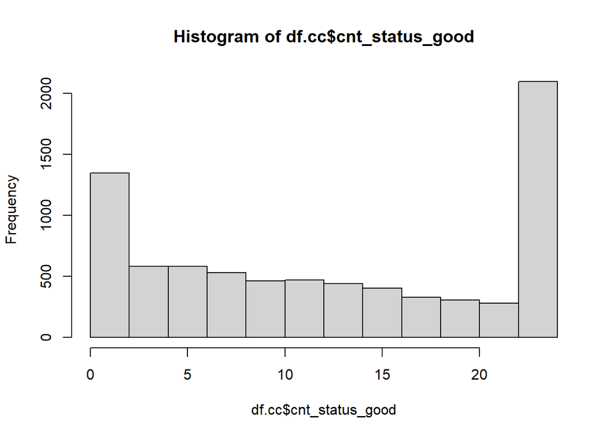

We also check the mean 12.75 and variance 77.79. As the variance is much greater than the mean, this suggests we will have over-dispersion in the model, suggesting a quasi-poisson model is more appropriate. We will start with a poisson model, regardless.

## 7.1 Graphical Analysis

From the plots below, it can be seen that name_income_type and occupation_type seem to have differences among levels with respect to counts. The other plots we have hidden as there were no clear differences among levels.

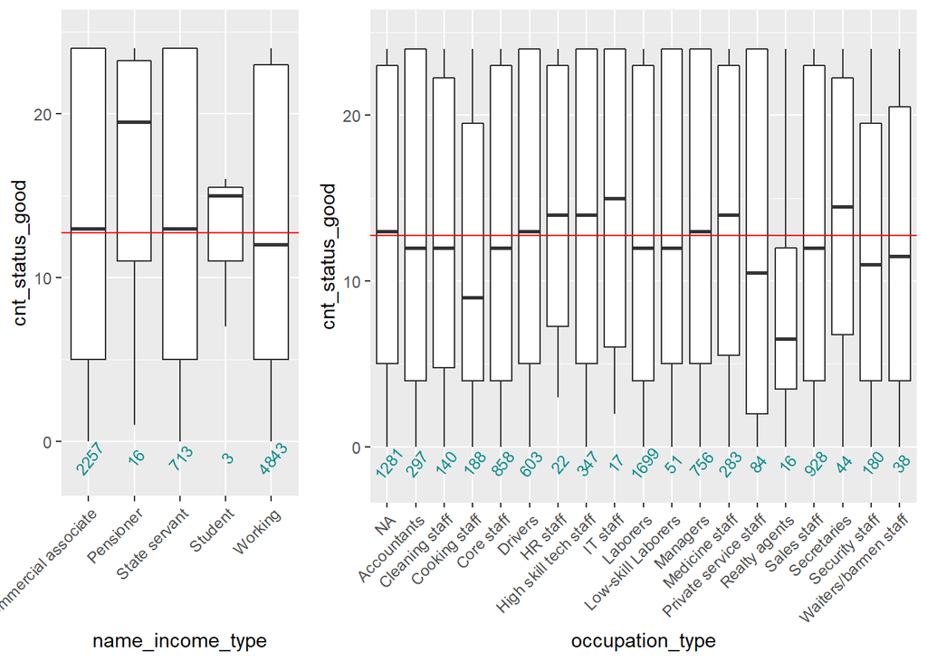

With name_income_type, we see that:  
- pensioners have higher much median than other income types  
- students have lowest variability, followed by pensioners

For occupation_type:  
- cooking staff & realty agents have lower median than other occupation types  
- variability is not constant among groups; realty agents also have much lower variability

## 7.2 Fit a Poisson Model

Now we fit the model using a poisson model with both variables and look at the result summary.

```r
fit.glm.p <- glm(cnt_status_good ~ name_income_type + occupation_type,
                 data = df.cc, family = poisson(link = "log"))
tail(capture.output(summary(fit.glm.p)), 8)
```

```
## [1] "(Dispersion parameter for poisson family taken to be 1)"
## [2] ""
## [3] "    Null deviance: 59397  on 7831  degrees of freedom"
## [4] "Residual deviance: 59201  on 7809  degrees of freedom"
## [5] "AIC: 89065"
## [6] ""
## [7] "Number of Fisher Scoring iterations: 5"
## [8] ""
```

Before interpreting the results, we check whether over- or under-dispersion exists. Here we confirm our initial suspicion that over-dispersion exists, since the *residual deviance* is greater than the degrees of freedom, meaning the estimates are correct, but the standard errors are not and thus unaccounted for by the model and we should use instead a *quasi-poisson* model:

```r
fit.glm.qp <- glm(cnt_status_good ~ name_income_type + occupation_type,
                  data = df.cc, family = quasipoisson(link = "log"))
tail(capture.output(summary(fit.glm.qp)), 8)
```

```
## [1] "(Dispersion parameter for quasipoisson family taken to be 6.105014)"
## [2] ""
## [3] "    Null deviance: 59397  on 7831  degrees of freedom"
## [4] "Residual deviance: 59201  on 7809  degrees of freedom"
## [5] "AIC: NA"
## [6] ""
## [7] "Number of Fisher Scoring iterations: 5"
## [8] ""
```

We see that the dispersion parameter has now increased, while null deviance and residual deviance with their respective degrees of freedom have remained unchanged.

## 7.3 Test if variables play a role

First, we start by testing the quasipoisson model with 2 predictor variables against a model that only includes the intercept.

```r
fit.glm.qp.0 <- update(fit.glm.qp, . ~ . - name_income_type - occupation_type)
anova(fit.glm.qp.0, fit.glm.qp, test = "F")
```

Here we saw weak evidence (not displayed) that at least one of the variables plays a role, so we compare the model with only the intercept against a quasi-poisson model that includes only one of the predictors. While we test both of our predictors, name_income_type and occupation_type, we show only one here.

```
## Analysis of Deviance Table
##
## Model 1: cnt_status_good ~ 1
## Model 2: cnt_status_good ~ occupation_type
##   Resid. Df Resid. Dev Df Deviance      F  Pr(>F)
## 1      7831      59397
## 2      7813      59229 18   168.32 1.5317 0.06924 .
## ---
## Signif. codes:  0 '***' 0.001 '**' 0.01 '*' 0.05 '.' 0.1 ' ' 1
```

From the outputs, we see there is weak evidence that occupation_type plays a role (above), however no evidence that name_income_type plays a role (not displayed), so we test again to compare a model with only occupation_type against the full model with both predictors.

```
## Analysis of Deviance Table
##
## Model 1: cnt_status_good ~ occupation_type
## Model 2: cnt_status_good ~ name_income_type + occupation_type
##   Resid. Df Resid. Dev Df Deviance      F Pr(>F)
## 1      7813      59229
## 2      7809      59201  4   28.597 1.1711 0.3214
```

There is no evidence that the more complex model is better, so we stick with the quasi-poisson model that includes only occupation_type as the predictor and check with summary() to verify a quasipoisson model is needed.

```
## [1] "(Dispersion parameter for poisson family taken to be 1)"
## [2] ""
## [3] "    Null deviance: 59397  on 7831  degrees of freedom"
## [4] "Residual deviance: 59229  on 7813  degrees of freedom"
## [5] "AIC: 89086"
## [6] ""
## [7] "Number of Fisher Scoring iterations: 5"
## [8] ""
```

This is confirmed as over-dispersion is again evident for the poisson model cnt_status_good ~ occupation_type.

## 7.4 Interpreting the coefficients

As the function *glm* takes the log, we remember to reverse this when interpreting the coefficients. Thus, we see the expected number of counts in reference group “NA” is 13, which is confirmed in the boxplot above.

Then we interpret the coefficients for the other groups.

```
##           Accountants        Cleaning staff         Cooking staff
##                 0.982                 0.965                 0.853
##            Core staff               Drivers              HR staff
##                 0.957                 1.000                 1.152
## High skill tech staff              IT staff              Laborers
##                 1.034                 1.114                 0.954
##    Low-skill Laborers              Managers        Medicine staff
##                 0.980                 0.996                 1.023
## Private service staff         Realty agents           Sales staff
##                 0.906                 0.692                 0.956
##           Secretaries        Security staff  Waiters/barmen staff
##                 1.039                 0.874                 0.932
```

As there are 19 levels, including the reference level, we will only include a few interpretations here.

For coefficients < 1, this indicates that we expect to see *fewer* cnt_status_good (i.e. status=0, 1 or C) than the reference level “NA”. For example,  
- Accountants: 1.8% fewer than “NA”  
- Cleaning staff: 3.5% fewer than “NA”  
- Cooking staff: 14.7% fewer than “NA”

For coefficients > 1, this indicates that we expect to see *more* cnt_status_good than the reference level “NA”. For example:  
- HR staff: 15.2% more than “NA”  
- IT staff: 11.4% more than “NA”  
- Secretaries: 3.9% more than “NA”

## 7.5 Test Contrasts

As we had determined that occupation_type plays a role, we now test the hypothesis whether the levels “Realty agents” and “Cooking staff” significantly differ from the others.

```
##
##   Simultaneous Tests for General Linear Hypotheses
##
## Multiple Comparisons of Means: User-defined Contrasts
##
##
## Fit: glm(formula = cnt_status_good ~ occupation_type, family = quasipoisson(link = "log"),
##     data = df.cc)
##
## Linear Hypotheses:
##        Estimate Std. Error z value Pr(>|z|)
## 1 == 0   0.2535     0.1076   2.355   0.0185 *
## ---
## Signif. codes:  0 '***' 0.001 '**' 0.01 '*' 0.05 '.' 0.1 ' ' 1
## (Adjusted p values reported -- single-step method)
```

This confirms the hypothesis from the graphical analysis, that there is a slight difference between “Realty agents”/“Cooking staff” and the other occupation types.

## 7.6 Conclusions

While there existed 2 count variables within our existing dataset (cnt_fam_members and cnt_children), predicting these variables served no practical purpose within the scope of our project. As the dependent variable in this case is correlated with the response variable from our linear model, the final model produced supports that occupation_type plays some role in repaying loans within 60 days.